# Análisis de factores que influyen en el índice GINI

Curso: POL304 - Estadística para el análisis político 2

Alexander Salazar, Sebastian Calero, Gianfranco Polar

2022-11-26

# Introducción

La siguiente investigación analiza los factores que pueden profundizar la desigualdad de ingreso en la sociedad. Aquí se analizarán tres posibles tipos de factores; laborales, sociales y económicos. El factor social será medido a través del nivel de democratización, población urbana, embarazo adolescente, matrícula escolar y mortalidad; el factor laboral se mide a través de la tasa de desempleo y fuerza de trabajo, y el factor económico por medio del nivel de exportaciones y gasto en educación.

```r
rm(list = ls())
library(kableExtra)
library(rio)
datafinal=import("https://github.com/AlexSalaz142/TrabajoE2/raw/main/datafinal.csv")
```

# 1. Análisis rápido de la data

En la introducción identificamos tres tipos de factores. Sin embargo, lo particular de estas variables presentadas es que pueden evaluarse de forma transversal (como es el caso del gasto en educación que tiene tanto una afectación social como una explicación económica), por lo que un análisis factorial nos permitirá confirmar a que área se acerca más cada variable.

# 2. Modelación

En este caso, se realizará una regresión lineal múltiple.

Modelo 1: Índice de desigualdad del ingreso = b0 + b1*Tasa de desempleo

```r
Modelrl=lm(gini~Unemployment, datafinal)
anova(Modelrl)
```

```
## Analysis of Variance Table
##
## Response: gini
##              Df Sum Sq Mean Sq F value    Pr(>F)
## Unemployment  1  756.7  756.70  14.535 0.0002405 ***
## Residuals    98 5102.0   52.06
## ---
## Signif. codes:  0 '***' 0.001 '**' 0.01 '*' 0.05 '.' 0.1 ' ' 1
```

```r
summary(Modelrl)
```

```
##
## Call:
## lm(formula = gini ~ Unemployment, data = datafinal)
##
## Residuals:
##     Min      1Q  Median      3Q     Max
## -12.779  -6.534  -0.504   5.108  17.932
##
## Coefficients:
##              Estimate Std. Error t value Pr(>|t|)
## (Intercept)   34.1893     1.2141  28.160  < 2e-16 ***
## Unemployment   0.4932     0.1294   3.812 0.000241 ***
## ---
## Signif. codes:  0 '***' 0.001 '**' 0.01 '*' 0.05 '.' 0.1 ' ' 1
##
## Residual standard error: 7.215 on 98 degrees of freedom
## Multiple R-squared:  0.1292, Adjusted R-squared:  0.1203
## F-statistic: 14.53 on 1 and 98 DF,  p-value: 0.0002405
```

```
gini = 34.1893 + 0.4932 * (Unemployment)
```

Podemos evidenciar que, en principio, se evidencia una relación estadísticamente significativa, por lo cual la variable de desempleo presentaría una correlación directa con la variable de desigualdad del ingreso. Esto básicamente indicaría que un país con mayor tasa de desemplo tiene mayor probabilidad de presentar una desigualdad económica más profunda.

Modelo 2: Índice de desigualdad del ingreso = b0 + b1 * Tasa de desempleo + b2 * Índice de democracia

```r
Modelrl2=lm(gini~Unemployment+DemoIndex, datafinal)
anova(Modelrl2)
```

```
## Analysis of Variance Table
##
## Response: gini
##              Df Sum Sq Mean Sq F value   Pr(>F)
## Unemployment  1  756.7  756.70 15.7592 0.000138 ***
## DemoIndex     1  444.5  444.47  9.2566 0.003019 **
## Residuals    97 4657.6   48.02
## ---
## Signif. codes:  0 '***' 0.001 '**' 0.01 '*' 0.05 '.' 0.1 ' ' 1
```

```r
summary(Modelrl2)
```

```
##
## Call:
## lm(formula = gini ~ Unemployment + DemoIndex, data = datafinal)
##
## Residuals:
##      Min       1Q   Median       3Q      Max
## -15.3306  -4.9636   0.0058   4.5884  15.6286
##
## Coefficients:
##              Estimate Std. Error t value Pr(>|t|)
## (Intercept)   39.8203     2.1875  18.204  < 2e-16 ***
## Unemployment   0.5517     0.1257   4.389  2.9e-05 ***
## DemoIndex     -1.0117     0.3325  -3.042  0.00302 **
## ---
## Signif. codes:  0 '***' 0.001 '**' 0.01 '*' 0.05 '.' 0.1 ' ' 1
##
## Residual standard error: 6.929 on 97 degrees of freedom
## Multiple R-squared:  0.205,  Adjusted R-squared:  0.1886
## F-statistic: 12.51 on 2 and 97 DF,  p-value: 1.47e-05
```

```
gini = 39.8203 + 0.5517 * (Unemployment) + -1.0117 * (DemoIndex)
```

Haber añadido el índice de democracia no ha alterado la significancia de la tasa de desempleo para el modelo. Por otro lado, el R Ajustado ha aumentado en un 0.0683, lo cual no es realmente mucho, mas indicaría que vamos por un buen camino. Además, a diferencia de la caso anterior, en este caso se expresaría una relación inversamente proporcional entre la desigualdad de ingreso y el índice de democracia. Esto implicaría que mientras un país se considere más democrático tiene más probabilidades de presentar menor desigualdad.

Modelo 3: Índice de desigualdad del ingreso = b0 + b1 * Tasa de desempleo + b2 * Índice de democracia + b3 * Porcentaje de gasto público en educación

```r
Modelrl3=lm(gini~Unemployment+DemoIndex+EducationExpenditure, datafinal)
anova(Modelrl3)
```

```
## Analysis of Variance Table
##
## Response: gini
##                      Df Sum Sq Mean Sq F value    Pr(>F)
## Unemployment          1  756.7  756.70 16.2865 0.0001094 ***
## DemoIndex             1  444.5  444.47  9.5663 0.0025954 **
## EducationExpenditure  1  197.3  197.25  4.2455 0.0420606 *
## Residuals            96 4460.3   46.46
## ---
## Signif. codes:  0 '***' 0.001 '**' 0.01 '*' 0.05 '.' 0.1 ' ' 1
```

```r
summary(Modelrl3)
```

```
##
## Call:
## lm(formula = gini ~ Unemployment + DemoIndex + EducationExpenditure,
##     data = datafinal)
##
## Residuals:
##      Min       1Q   Median       3Q      Max
## -15.8467  -4.9989   0.1141   4.3801  15.8769
##
## Coefficients:
##                      Estimate Std. Error t value Pr(>|t|)
## (Intercept)           34.4955     3.3628  10.258  < 2e-16 ***
## Unemployment           0.5596     0.1237   4.523 1.74e-05 ***
## DemoIndex             -0.9334     0.3293  -2.835  0.00559 **
## EducationExpenditure   0.3292     0.1597   2.060  0.04206 *
## ---
## Signif. codes:  0 '***' 0.001 '**' 0.01 '*' 0.05 '.' 0.1 ' ' 1
##
## Residual standard error: 6.816 on 96 degrees of freedom
## Multiple R-squared:  0.2387, Adjusted R-squared:  0.2149
## F-statistic: 10.03 on 3 and 96 DF,  p-value: 8.201e-06
```

```
gini = 34.4955 + 0.5596 * (Unemployment) + -0.9334 * (DemoIndex) + 0.3292 * (Education expenditure)
```

El modelo 3 explica el coeficiente de GINI (Y) en un 21% a partir de las variables independientes del porcentaje de desempleo (Unemployment), el índice de la democracia (DemoIndex) y el porcentaje de gasto en educación (Education expenditure). Sin embargo, un 21% de variación no es especialmente útil para la extrapolación final de los resultados a la realidad, cosa que se arreglaría con la inclusión de las demás variables.

Podemos notar como 2 de las 3 variables independientes resultan bastante relevantes. El porcentaje de gasto en educación resulta estadísticamente significativo, pero se acerca mucho al 0.05. Se puede preveer a partir de lo último que perdería su significancia al incluirse más variables al modelo.

Ahora, para evidenciar clararamente cuál es la variable de mayor efecto sobre la variable dependiente, podemos estandarizarlas:

```r
library(lm.beta)
lm.beta(Modelrl3)
```

```
##
## Call:
## lm(formula = gini ~ Unemployment + DemoIndex + EducationExpenditure,
##     data = datafinal)
##
## Standardized Coefficients::
##          (Intercept)         Unemployment            DemoIndex
##                   NA            0.4078000           -0.2571625
## EducationExpenditure
##            0.1849416
```

Esto nos muestra que definitivamente la variable de desempleo es la variable con mayor peso para el modelo.

Podemos igualmente comparar estos tres primeros modelos gráficamente:

```r
library(stargazer)
library(jtools)
stargazer(Modelrl,Modelrl2,Modelrl3, type ="text")
```

```
##
## =========================================================================================
##                                              Dependent variable:
##                      --------------------------------------------------------------------
##                                                      gini
##                               (1)                    (2)                    (3)
## -----------------------------------------------------------------------------------------
## Unemployment                0.493***               0.552***               0.560***
##                             (0.129)                (0.126)                (0.124)
##
## DemoIndex                                         -1.012***              -0.933***
##                                                    (0.333)                (0.329)
##
## EducationExpenditure                                                      0.329**
##                                                                           (0.160)
##
## Constant                   34.189***              39.820***              34.495***
##                             (1.214)                (2.187)                (3.363)
##
## -----------------------------------------------------------------------------------------
## Observations                  100                    100                    100
## R2                           0.129                  0.205                  0.239
## Adjusted R2                  0.120                  0.189                  0.215
## Residual Std. Error     7.215 (df = 98)        6.929 (df = 97)        6.816 (df = 96)
## F Statistic          14.535*** (df = 1; 98) 12.508*** (df = 2; 97) 10.033*** (df = 3; 96)
## =========================================================================================
## Note:                                                         *p<0.1; **p<0.05; ***p<0.01
```

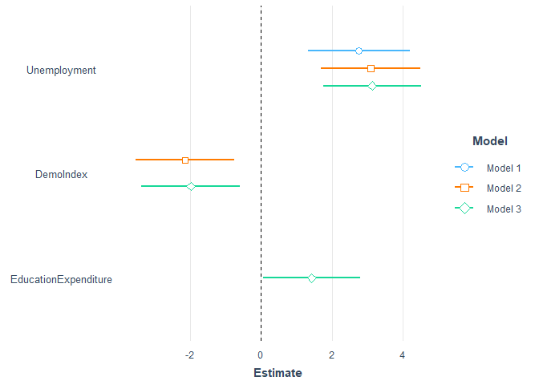

```r
plot_summs(Modelrl,Modelrl2,Modelrl3, scale = TRUE)
```

Realizar otra regresión con las otras variables independientes:

Modelo 4:

```r
Modelrl4=lm(gini~urb_pop+exports+school_enr, datafinal)
anova(Modelrl4)
```

```
## Analysis of Variance Table
##
## Response: gini
##            Df Sum Sq Mean Sq F value  Pr(>F)
## urb_pop     1  183.7 183.743  3.3841 0.06892 .
## exports     1  192.0 192.009  3.5363 0.06307 .
## school_enr  1  270.5 270.515  4.9822 0.02794 *
## Residuals  96 5212.5  54.297
## ---
## Signif. codes:  0 '***' 0.001 '**' 0.01 '*' 0.05 '.' 0.1 ' ' 1
```

```r
summary(Modelrl4)
```

```
##
## Call:
## lm(formula = gini ~ urb_pop + exports + school_enr, data = datafinal)
##
## Residuals:
##      Min       1Q   Median       3Q      Max
## -12.6172  -4.7556  -0.6295   4.6093  23.8751
##
## Coefficients:
##             Estimate Std. Error t value Pr(>|t|)
## (Intercept) 24.83952    7.31936   3.394   0.0010 **
## urb_pop     -0.04050    0.03295  -1.229   0.2221
## exports      0.11311    0.05300   2.134   0.0354 *
## school_enr   0.13770    0.06169   2.232   0.0279 *
## ---
## Signif. codes:  0 '***' 0.001 '**' 0.01 '*' 0.05 '.' 0.1 ' ' 1
##
## Residual standard error: 7.369 on 96 degrees of freedom
## Multiple R-squared:  0.1103, Adjusted R-squared:  0.08251
## F-statistic: 3.968 on 3 and 96 DF,  p-value: 0.01031
```

El modelo explica la desigualdad en la distribución de los ingresos (coeficiente de Gini) con un R2 Ajustado de 0.08251, lo cual podría explicar la variable dependiente pero no resulta lo suficientemente significativo como para concluir que es de gran relevancia.

Modelo 5:

```r
Modelrl5=lm(gini~teen_preg+death_rate+labor_force, datafinal)
anova(Modelrl5)
```

```
## Analysis of Variance Table
##
## Response: gini
##             Df Sum Sq Mean Sq F value    Pr(>F)
## teen_preg    1 1921.1 1921.05 49.0841 3.373e-10 ***
## death_rate   1  180.4  180.42  4.6097   0.03431 *
## labor_force  1    0.0    0.03  0.0007   0.97957
## Residuals   96 3757.3   39.14
## ---
## Signif. codes:  0 '***' 0.001 '**' 0.01 '*' 0.05 '.' 0.1 ' ' 1
```

```r
summary(Modelrl5)
```

```
##
## Call:
## lm(formula = gini ~ teen_preg + death_rate + labor_force, data = datafinal)
##
## Residuals:
##      Min       1Q   Median       3Q      Max
## -17.4834  -4.3203  -0.4593   3.4182  23.2200
##
## Coefficients:
##              Estimate Std. Error t value Pr(>|t|)
## (Intercept) 37.159468   4.754041   7.816 6.94e-12 ***
## teen_preg    0.103112   0.015955   6.462 4.26e-09 ***
## death_rate  -0.455327   0.212474  -2.143   0.0346 *
## labor_force -0.001572   0.061241  -0.026   0.9796
## ---
## Signif. codes:  0 '***' 0.001 '**' 0.01 '*' 0.05 '.' 0.1 ' ' 1
##
## Residual standard error: 6.256 on 96 degrees of freedom
## Multiple R-squared:  0.3587, Adjusted R-squared:  0.3387
## F-statistic:  17.9 on 3 and 96 DF,  p-value: 2.634e-09
```

El modelo explica la desigualdad en la distribución de los ingresos (coeficiente de Gini) con un R2 Ajustado de 0.3387, lo cual parece tener una cierta relevancia. La variable fertilidad adolescente (teen_preg), es la que más influye en el modelo, pues tiene un valor de 4.26e-09 y presenta tres asteriscos, por lo cual está bien relacionada a la variable dependiente. La variable mortalidad (death_rate) presenta también cierta significancia pues está acompañada de un asterisco y un valor de 0.0346. Por último, la variable fuerza laboral es la que menos aporta al modelo.

Regresión final - Modelo 6:

```r
Modelrl6=lm(gini~Unemployment+DemoIndex+EducationExpenditure+urb_pop+exports+school_enr+teen_preg+death_rate+labor_force, datafinal)
anova(Modelrl6)
```

```
## Analysis of Variance Table
##
## Response: gini
##                      Df  Sum Sq Mean Sq F value    Pr(>F)
## Unemployment          1  756.70  756.70 25.9003 1.954e-06 ***
## DemoIndex             1  444.47  444.47 15.2132 0.0001848 ***
## EducationExpenditure  1  197.25  197.25  6.7515 0.0109438 *
## urb_pop               1   21.14   21.14  0.7237 0.3971894
## exports               1   57.77   57.77  1.9772 0.1631237
## school_enr            1  163.64  163.64  5.6010 0.0200947 *
## teen_preg             1 1356.81 1356.81 46.4410 1.041e-09 ***
## death_rate            1  181.41  181.41  6.2092 0.0145402 *
## labor_force           1   50.13   50.13  1.7158 0.1935673
## Residuals            90 2629.43   29.22
## ---
## Signif. codes:  0 '***' 0.001 '**' 0.01 '*' 0.05 '.' 0.1 ' ' 1
```

```r
summary(Modelrl6)
```

```
##
## Call:
## lm(formula = gini ~ Unemployment + DemoIndex + EducationExpenditure +
##     urb_pop + exports + school_enr + teen_preg + death_rate +
##     labor_force, data = datafinal)
##
## Residuals:
##      Min       1Q   Median       3Q      Max
## -10.6931  -4.2033   0.6736   3.5423  11.2109
##
## Coefficients:
##                       Estimate Std. Error t value Pr(>|t|)
## (Intercept)          15.826971   7.181096   2.204   0.0301 *
## Unemployment          0.570772   0.112216   5.086 1.98e-06 ***
## DemoIndex            -0.075890   0.347991  -0.218   0.8279
## EducationExpenditure  0.071268   0.138661   0.514   0.6085
## urb_pop               0.039920   0.033063   1.207   0.2304
## exports              -0.002903   0.041043  -0.071   0.9438
## school_enr            0.077891   0.048134   1.618   0.1091
## teen_preg             0.110002   0.017827   6.170 1.91e-08 ***
## death_rate           -0.519934   0.201856  -2.576   0.0116 *
## labor_force           0.082887   0.063278   1.310   0.1936
## ---
## Signif. codes:  0 '***' 0.001 '**' 0.01 '*' 0.05 '.' 0.1 ' ' 1
##
## Residual standard error: 5.405 on 90 degrees of freedom
## Multiple R-squared:  0.5512, Adjusted R-squared:  0.5063
## F-statistic: 12.28 on 9 and 90 DF,  p-value: 1.815e-12
```

[output not shown]

El modelo 6 reune todas las variables contempladas para la predicción de la desigualdad del ingreso. Se presenta un R ajustado de un 0.5063, superior al de todos los anteriores modelos, por lo que ya debería considerarse a priori como el modelo más adecuado. No obstante, hay que tener en cuenta algunas aristas.

En primer lugar, solo 3 de las 9 variables se identificarían como estadísticamente significantes. Estas son el desempleo, el embarazo adolescente y la mortalidad. A pesar de las aparentes inconveniencias, hay que reconocer que las variables no mencionadas desde un principio no presentaban un aporte relevante para la explicación de la desigualdad económica.

Vamos a estandarizarlas para revisar la afectación:

```r
lm.beta(Modelrl6)
```

```
##
## Call:
## lm(formula = gini ~ Unemployment + DemoIndex + EducationExpenditure +
##     urb_pop + exports + school_enr + teen_preg + death_rate +
##     labor_force, data = datafinal)
##
## Standardized Coefficients::
##          (Intercept)         Unemployment            DemoIndex
##                   NA          0.415937194         -0.020907992
## EducationExpenditure              urb_pop              exports
##          0.040043561          0.119289034         -0.005322699
##           school_enr            teen_preg           death_rate
##          0.124739273          0.574223521         -0.204059395
##          labor_force
##          0.110790407
```

De esta manera, se identifica al embarazo adolescente como la variable con mayor efecto sobre la desigualdad de ingreso.

En segundo lugar, se evidencia que, en base al signo de los coeficientes, la relación del desempleo y el embarazo adolescente con la desigualdad de ingreso es directamente proporcional, mientras que la la relación de la mortalidad con la desigualdad es inversamente proporcional.

Finalmente, podemos establecer 3 correlaciones fuertes o medianamente fuertes, por lo cual se puede afirmar que la desigualdad de ingreso se explica por el desempleo, el embarazo adolescente y la mortalidad. Esto significa que, cuando un país presenta una mayor tasa de desempleo y de embarazo adolescente, es más probable que dicho país observe una mayor desigualdad del ingreso en relación con los demás países con tasas menores. Por la otra parte, mientras un país presente una mayor tasa de mortalidad, hay más posibilidades de que tal observe una menor desigualdad.

Graficamos para compararlo con los 3 principales modelos:

```r
stargazer(Modelrl3, Modelrl4, Modelrl5, Modelrl6, type ="text")
```

```
##
## ==============================================================================================================
##                                                         Dependent variable:
##                      -----------------------------------------------------------------------------------------
##                                                                gini
##                               (1)                   (2)                   (3)                    (4)
## --------------------------------------------------------------------------------------------------------------
## Unemployment                0.560***                                                           0.571***
##                             (0.124)                                                            (0.112)
##
## DemoIndex                  -0.933***                                                            -0.076
##                             (0.329)                                                            (0.348)
##
## EducationExpenditure        0.329**                                                             0.071
##                             (0.160)                                                            (0.139)
##
## urb_pop                                            -0.040                                       0.040
##                                                   (0.033)                                      (0.033)
##
## exports                                           0.113**                                       -0.003
##                                                   (0.053)                                      (0.041)
##
## school_enr                                        0.138**                                       0.078
##                                                   (0.062)                                      (0.048)
##
## teen_preg                                                               0.103***               0.110***
##                                                                         (0.016)                (0.018)
##
## death_rate                                                              -0.455**               -0.520**
##                                                                         (0.212)                (0.202)
##
## labor_force                                                              -0.002                 0.083
##                                                                         (0.061)                (0.063)
##
## Constant                   34.495***             24.840***             37.159***               15.827**
##                             (3.363)               (7.319)               (4.754)                (7.181)
##
## --------------------------------------------------------------------------------------------------------------
## Observations                  100                   100                   100                    100
## R2                           0.239                 0.110                 0.359                  0.551
## Adjusted R2                  0.215                 0.083                 0.339                  0.506
## Residual Std. Error     6.816 (df = 96)       7.369 (df = 96)       6.256 (df = 96)        5.405 (df = 90)
## F Statistic          10.033*** (df = 3; 96) 3.968** (df = 3; 96) 17.898*** (df = 3; 96) 12.281*** (df = 9; 90)
## ==============================================================================================================
## Note:                                                                              *p<0.1; **p<0.05; ***p<0.01
```

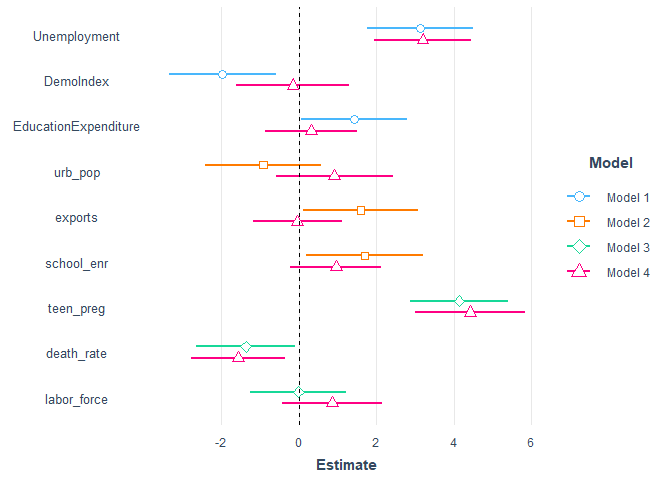

```r
plot_summs(Modelrl3, Modelrl4, Modelrl5, Modelrl6, scale = TRUE)
```

Vemos como los intervalos de mortalidad, embarazo adolescente y desempleo son las únicos que no cruzan por el 0, lo que explica la significancia.

A partir de todo esto, concluimos que la tesis de que una alta tasa de mortalidad implica ingresos más desiguales debe ser rechazada. Es cierto que si existe una menor tasa de mortalidad existirá mayor cantidad de gente que pueda generar más ingresos, pero habría que identificar en qué grupos etarios se focaliza esta mortilidad, puesto que, dependiendo de la edad, una persona percibe más o menos ingresos o no los recibe en absoluto. En ese sentido, por muy cínico que suene, habría que evaluar en que mayor medida el fallecimiento de unas personas por sobre el de otras afecta al ingreso familiar. Un objetivo posterior consistiría por tanto en descubrir que características de la persona determinan el nivel de afectación.

Por su parte, la hipótesis de que el embarazo adolescente implica mayor desigualdad puede considerarse como correcta. El caso es que, las adolescentes que quedan embarazadas encuentran complicaciones con el seguimiento de estudios, lo que a su vez implica una limitación a la empleabilidad. Además, un hij@ acarrea consigo un aumento a los gastos familiares, por lo que el ingreso percibido tras la cobertura de los gastos es finalmente menor al ingreso neto de quien no tiene una responabilidad con un menor.

Por último, el argumento de que la afectación del desempleo en la desigualdad del ingreso debería considerarse de manera sistemática debe no ser rechazado, pero si cuestionarse. Si, por el contrario, el modelo hubiese arrojado que no existía una correlación entre estas variables, ello podría interpretarse como que el nivel de desarrollo entendido en términos de estabilidad laboral o no se relaciona con la desigualdad económica, o no se evidencia en la realidad. Dado que ese no es el caso, es más fácil suponer que los países con menores tasas de desempleo (que en su mayoría se tratarían de países desarrollados) son menos desiguales. Pero, consideramos que no hay que caer en el error de imponerla como una variable causal, pues el análisis de correlación no toma en cuenta la relación con las otras variables como la democratización, lo cual se intentará resolver adelante con el análisis factorial.

# 3. Análisis factorial

En esta sección deseamos evaluar si es posible reducir neustras variables a otras más simples. Como se mencionó al principio, consideramos que la desigualdad se explica por tres tipos de factores, por lo que aquí se mostrará si esta interpretación es correcta.

3.1. Anális factorial exploratorio:

Primero substeamos la data para quedarnos con las variables de interés:

```r
dontselect=c("country","gini", "DemoIndex") #No incluiremos el índice de la Democracia por tratarse de una variable latente en sí misma, construida a partir de variables propias.
select=setdiff(names(datafinal),dontselect)
theData=datafinal[,select]
```

Calculamos la matriz de correlación

```r
library(polycor)
corMatrix=polycor::hetcor(theData)$correlations
```

Visibilizamos el nivel de correlación:

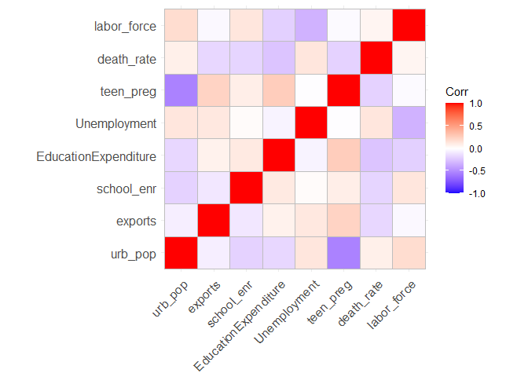

```r
library(ggcorrplot)
ggcorrplot(corMatrix)
```

Con este gráfico se visualiza que la formación de factores no es del todo clara, pero podría intuirse la agrupación de variables como la tasa de mortalidad, la fuerza laboral y el desempleo.

Igualmente es imprescindible verificar si las datos permiten la factorización:

```r
library(psych)
psych::KMO(corMatrix)
```

```
## Kaiser-Meyer-Olkin factor adequacy
## Call: psych::KMO(r = corMatrix)
## Overall MSA =  0.43
## MSA for each item =
##              urb_pop              exports           school_enr
##                 0.44                 0.50                 0.32
## EducationExpenditure         Unemployment            teen_preg
##                 0.60                 0.30                 0.51
##           death_rate          labor_force
##                 0.50                 0.31
```

El MSA (medida de suficiencia de la muestra) general (0.43) resulta adecuado (>= 0.40), por lo cual el análisis factorial resultaría pertinente. Sin embargo, hemos de advertir que ciertas variables (la tasa de matrícula escolar y de la fuerza laboral) presentan inconvenientes con el hecho de superar la medida de suficiencia mínima, por lo cual es probable que sean eliminadas del análisis. Más adelante confirmaremos si esta dificultad persiste.

Se verifica si la matriz de correlación es adecuada, rechazando nuestras 2 hipótesis nulas:

H1: Se trata de una matriz de identidad (Esfericidad de Bartlett):

```r
cortest.bartlett(corMatrix,n=nrow(theData))$p.value>0.05
```

```
## [1] FALSE
```

H2: Se trata de una matriz singular:

```r
library(matrixcalc)
is.singular.matrix(corMatrix)
```

```
## [1] FALSE
```

Confirmamos que no nos encontramos ante una matriz que lleve a la indeterminación, por lo que el análisis factorial es factible.

De esta manera, podemos pasar a redimensionamos la data de acuerdo a nuestra hipótesis inicial sobre 3 tipos de factores:

```r
library(GPArotation)
resfa <- fa(theData,
            nfactors = 3,
            cor = 'mixed',
            rotate = "varimax",
            fm="minres")
print(resfa$loadings)
```

```
##
## Loadings:
##                      MR1    MR2    MR3
## urb_pop               0.924
## exports                            -0.194
## school_enr           -0.141  0.163 -0.153
## EducationExpenditure -0.198        -0.366
## Unemployment                -0.346
## teen_preg            -0.563        -0.275
## death_rate                  -0.144  0.790
## labor_force           0.148  0.967  0.218
##
##                  MR1   MR2   MR3
## SS loadings    1.264 1.114 0.954
## Proportion Var 0.158 0.139 0.119
## Cumulative Var 0.158 0.297 0.416
```

La varianza acumulada nos muestra que se a recuperado un 41% de los datos, por lo cual no estamos ante una muy buena representación de la realidad.

Podemos establecer un mínimo para los scores (>0.5) para identificar claramente qué variables se adecúan más a los factores.

```r
print(resfa$loadings, cutoff = 0.5)
```

```
##
## Loadings:
##                      MR1    MR2    MR3
## urb_pop               0.924
## exports
## school_enr
## EducationExpenditure
## Unemployment
## teen_preg            -0.563
## death_rate                          0.790
## labor_force                  0.967
##
##                  MR1   MR2   MR3
## SS loadings    1.264 1.114 0.954
## Proportion Var 0.158 0.139 0.119
## Cumulative Var 0.158 0.297 0.416
```

Vemos que tan solo 4 variables superan esta valla, lo que sugiere que la agrupación no es del todo adecuada.

La agrupación se visibiliza con mayor claridad en el siguiente gráfico:

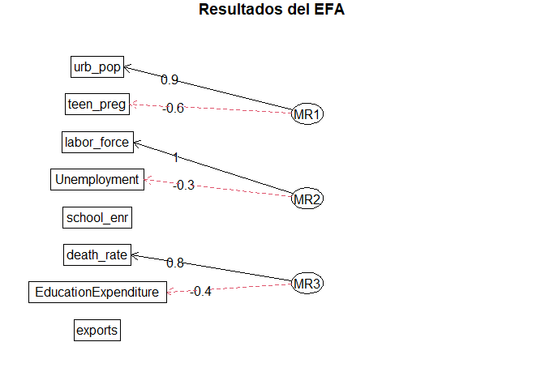

```r
fa.diagram(resfa,main = "Resultados del EFA")
```

De ello se resuelve que el porcentaje de población urbana y de embarazo adolescente se agrupan en un factor, el cual podríamos considerar como el factor social. Por el otro lado, el porcentaje de fuerza laboral y de desempleo se agrupan en un segundo factor, el cual habíamos previsto como el factor laboral. Por último, la tasa de mortalidad y el porcentaje de gasto en educación componen el tercer factor. No obstante, esto último nos resulta conflictivo en tanto el porcentaje de mortalidad presenta una correlación muy baja con el gasto en eduación según la matriz. Asimismo, las variables de tasa de matrícula escolar y el porcentaje de exportaciones de metales y minerales se estarían quedando fuera del estudio.

Es por ello que hay que ser más específicos respecto a la afectación a las variables latentes. Evaluamos la contribución de las variables a la formación de factores:

```r
sort(resfa$communality)
```

```
##              exports           school_enr         Unemployment
##           0.04678396           0.06986764           0.12629570
## EducationExpenditure            teen_preg           death_rate
##           0.17815855           0.39937204           0.64500019
##              urb_pop          labor_force
##           0.86304851           1.00343459
```

De esta prueba se resuelve que la fuerza laboral es la variable que más tiende a agruparse con las demás variables. Por el otro lado, la variable con la menor comunalidad se trata del porcentaje de exportaciones de metales y minerales, por es la principal variable a ser considerada como no apta para el estudio.

Evaluamos qué variables aportan a más de un factor:

```r
sort(resfa$complexity)
```

```
##              urb_pop           death_rate         Unemployment
##             1.022546             1.066806             1.108552
##          labor_force              exports            teen_preg
##             1.150069             1.468049             1.497618
## EducationExpenditure           school_enr
##             1.626745             2.959100
```

Se concluye que la variable más compleja es la tasa de matrícula escolar, lo que implica que es la que más tiende a pertencer a ambos factores, pero en sí misma no pertenece claramente a ninguno. Por su parte, la variable con menor probabilidad de acercarse a más de un factor es el porcentaje de población urbana, la cual pertenecería de forma rígida al primer factor.

# 4. Analisis Conglomerados

Con este análisis queremos si los países presentan similitudes de acuerdo a nuestras variables analizadas. El objetivo final es evidenciar qué tan bien se agrupan los casos.

## Preparación de los datos para la clusterización

Como primer paso, hay que normalizar la data:

```r
library(BBmisc)
datafinal[,c(3:11)]= normalize(datafinal[,c(3:11)],method='standardize')
```

Luego evidenciamos las correlaciones:

```r
cor(datafinal[,c(3:11)])
```

```
##                          urb_pop     exports  school_enr EducationExpenditure
## urb_pop               1.00000000 -0.06687834 -0.19144207          -0.17213377
## exports              -0.06687834  1.00000000 -0.10442963           0.06598594
## school_enr           -0.19144207 -0.10442963  1.00000000           0.10799359
## EducationExpenditure -0.17213377  0.06598594  0.10799359           1.00000000
## Unemployment          0.13195804  0.12277635  0.01869685          -0.04885578
## DemoIndex             0.58665105 -0.13090135 -0.15374865          -0.12131736
## teen_preg            -0.54216991  0.22948657  0.09091606           0.26430274
## death_rate            0.08250674 -0.16806001 -0.18410512          -0.25371616
## labor_force           0.17670292 -0.03356330  0.13062140          -0.20011506
##                      Unemployment  DemoIndex   teen_preg  death_rate
## urb_pop                0.13195804  0.5866511 -0.54216991  0.08250674
## exports                0.12277635 -0.1309013  0.22948657 -0.16806001
## school_enr             0.01869685 -0.1537487  0.09091606 -0.18410512
## EducationExpenditure  -0.04885578 -0.1213174  0.26430274 -0.25371616
## Unemployment           1.00000000  0.1531329 -0.01016978  0.13098984
## DemoIndex              0.15313293  1.0000000 -0.47206102  0.28285883
## teen_preg             -0.01016978 -0.4720610  1.00000000 -0.19204820
## death_rate             0.13098984  0.2828588 -0.19204820  1.00000000
## labor_force           -0.32714985  0.2004693 -0.02219815  0.05388013
##                      labor_force
## urb_pop               0.17670292
## exports              -0.03356330
## school_enr            0.13062140
## EducationExpenditure -0.20011506
## Unemployment         -0.32714985
## DemoIndex             0.20046929
## teen_preg            -0.02219815
## death_rate            0.05388013
## labor_force           1.00000000
```

Finalmente, se subseteará la data pertinente para la clusterización:

```r
dataClus=datafinal[,c(3:11)]
row.names(dataClus)=datafinal$country
```

## Proceso de clusterización

Para realizar el proceso de clusterización se hará uso de la Estrategia Jerárquica - divisiva, mediante la cual todos los casos empezarán como un gran cluster y de ahí se dividirán en clusters más pequeños.

```r
library(cluster)
g.dist = daisy(dataClus, metric="gower")
```

Ahora se decidirá la cantidad de cluster a utilizar mediante una solicitud usando el estadístico ‘gap’:

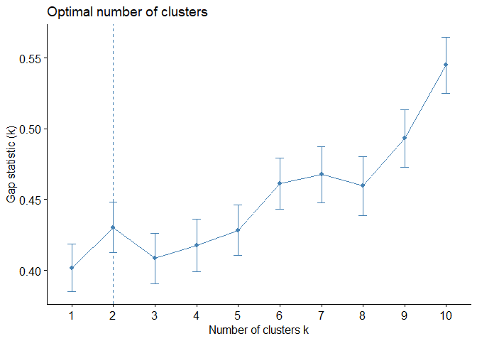

### Clusterizar vía DIANA

Se realiza la clusterización:

```
##                 urb_pop      exports  school_enr EducationExpenditure
## Afghanistan -1.52668790 -0.548356193 -0.17732302          -0.99852703
## Albania      0.06788064 -0.003864406 -0.01429447          -0.57835634
## Algeria      0.55910606 -0.610225132  0.82459855           0.45792142
## Angola       0.26324845 -0.376906426  0.62979748          -1.87457915
## Argentina    1.34075133 -0.400171841  0.45328705          -0.47191727
## Armenia      0.08797860  1.829430412 -0.86978438          -1.32845621
## Australia    1.08552466  1.606920725 -0.33435811          -0.25277436
## Austria     -0.10499661 -0.405290772 -0.30208644          -0.89081797
## Azerbaijan  -0.20152771 -0.550378694  0.07162603          -0.94099637
## Belarus      0.80484928 -0.540564582 -0.53323780          -0.41382906
## Belgium      1.59689155 -0.456931979 -0.20806381          -0.54469432
## Benin       -0.54101790 -0.462557136  2.17114777           0.72628958
## Bolivia      0.39440721  1.684918888 -0.79634127          -0.08557275
## Botswana     0.44160696 -0.342098824 -0.20136064           0.18111261
## Brazil       1.12706915  0.208126113  0.62103209           0.36518760
##             Unemployment   DemoIndex   teen_preg  death_rate labor_force diana
## Afghanistan   0.74233820 -1.48767897  0.32816186 -0.65708648 -2.00015742     1
## Albania       1.03113794  0.03633089 -0.62000278  0.04044771 -0.14070384     2
## Algeria       0.89217870 -1.05359567 -0.87086083 -1.13370173 -2.40083466     2
## Angola        0.13994389 -1.10549693  2.45262859 -0.11356625  0.66843077     1
## Argentina     0.69774283  0.44682270  0.44328892 -0.17848396 -0.16404426     2
## Armenia       2.43624885 -0.30810478 -0.61390676  0.54985302 -0.92455300     2
## Australia    -0.19416470  1.39520035 -0.84127722 -0.60972305  0.72483679     2
## Austria      -0.39038433  1.01773661 -0.94323110  0.71512822  0.56437139     2
## Azerbaijan   -0.19362959 -1.56789002  0.33582671 -0.21226767  0.09561793     1
## Belarus      -0.49598619 -1.61035469 -0.79910812  1.60940282  0.68107350     2
## Belgium      -0.35649184  0.71104732 -0.99413085  0.94697719 -0.19419231     2
## Benin        -1.06395292 -0.67141363  0.88617149  0.14113641  0.05866226     1
## Bolivia       0.06270468 -0.43549879  0.43782044 -0.45670273  0.30665424     2
## Botswana      3.10054175  0.76294859 -0.00943493 -0.80248891  0.19384220     2
## Brazil        1.09553350  0.43266781  0.27652502 -0.50572223 -0.01233152     2
```

Se evalúan las siluetas formadas:

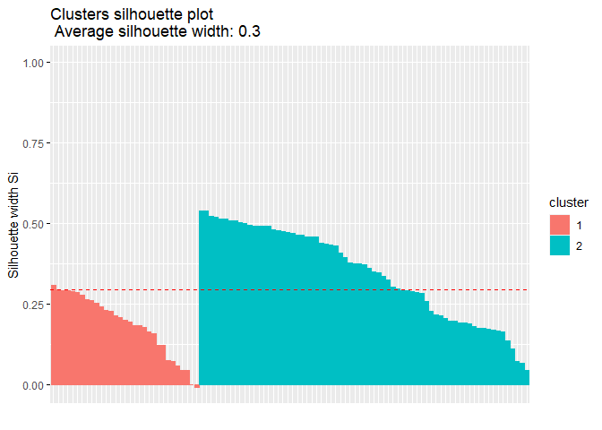

Con este gráfico podemos evidenciar barras que representan cada caso analizado, o sea los países. Mientras más baja la barra es menos probable que el país guarde similitudes con el resto de casos del subgrupo y los que se encuentran por debajo del 0 se tratan de países mal clusterizados, los cuales se tratan de los casos que, de acuerdo al análisis, no pertenecen a ningun grupo, pero son forzados por la prueba a serlo.

- Lamentablemente, se muestran ciertos casos mal clusterizados, por lo que es preciso identificarlos:

```r
silDIANA=data.frame(res.diana$silinfo$widths)
silDIANA$country=row.names(silDIANA)
poorDIANA=silDIANA[silDIANA$sil_width<0,'country']%>%sort()
poorDIANA
```

```
## [1] "Azerbaijan"
```

### Verificando Etiqueta

- A continuación, exploraremos el promedio de cada cluster.

```
##   diana    urb_pop    exports school_enr EducationExpenditure Unemployment
## 1     1 -1.1100784  0.2399714  0.3287721            0.3585037   -0.2487782
## 2     2  0.4987309 -0.1078133 -0.1477092           -0.1610669    0.1117699
##    DemoIndex  teen_preg death_rate labor_force
## 1 -0.9560335  1.0545503 -0.3059902 -0.04395403
## 2  0.4295223 -0.4737835  0.1374739  0.01974746
```

Las etiquetas sí muestran un orden, por lo que no hay que reconfigurarlo.

Guardemos la columna de DIANA en la data integrada y la eliminamos de dataClus.

```r
datafinal$dianaGINIpoor=datafinal$country%in%poorDIANA
datafinal$dianaGINI=as.ordered(dataClus$diana)
dataClus$diana=NULL
```

# 5. Conclusiones

En conclusión, las variables independientes escogidas para la investigación conforman un modelo de regresión lineal que explica la variable dependiente en un 55%. De estas variables, aquellas que resultan más estadísticamente significativas en el modelo propuesto son la tasa de mortalidad, la tasa de desempleo y la tasa de embarazo adolescente, en comparación con el resto de variables. El modelo mejora a medida que se añaden nuevas variables, aunque estas no logran ser lo suficientemente significativas para explicar la desigualdad en la distribución del ingreso. Es posible concluir, entonces, que la ocurrencia de embarazos adolescentes explica en cierta medida las malas condiciones de vida propias de un país con desigualdad en la distribución del ingreso. Por otro lado, variables como la exportación de metales y minerales con respecto al total de exportaciones no explica la desigualdad, por lo cual es posible afirmar que la desigualdad no es un fenómeno exclusivo de países exportadores de materias primas. Es posible establecer 3 correlaciones fuertes o medianamente fuertes, por lo cual la desigualdad en la distribución del ingreso se explica por el desempleo, el embarazo adolescente y la mortalidad.

Con respecto a la reducción de la dimensionalidad, el análisis factorial de las variables nos indica que es posible reducirlas a tres factores, que presentan cierta similtud en sus ámbitos, y provienen de sólo algunas variables de la investigación con significancia estadística. Por un lado, se encuentra el factor demográfico (RM1), que se compone del porcentaje de población urbana y la tasa de embarazo adolescente. En segundo lugar, se encuentra el factor laboral (MR2), compuesto por la fuerza laboral y la tasa de desempleo. Por último, se encuentra el factor MR3 que agrupa variables sin mucha relación entre sí: la tasa de mortalidad y el porcentaje de gasto en educación. La variable fuerza laboral es la que tiende a agruparse más con otras, a diferencia de la exportación de metales y minerales.